# Module 2 Report - DATA2002 Student Survey

470336432, 470402449, 470378568

Semester 2 2019

$~$

# 1. Data Import

```r
options(scipen=999) # stops the scientific notation
options(warn=-1)
x = readr::read_csv("data.csv", na = c("NA",""," ", "n/a"))
```

$~$ $~$

# 2. Data Exploration

The dataset used comes from a class survey of the students in DATA2002. There were 110 respondents who each answered 22 questions about themselves. A timestamp variable of when respondents completed the survey is also included.

### 2.1 Randomisation of Sample

No, this data is not a random sample of students from DATA2002 because, whilst only a sample or subset of students completed the survey, means that only a ‘type of student’ is reflected in the sample. Given the survey was on an ‘opt-in’ basis, it may reflect only more high achieving or higher motivated students who had the time and made the active decision to complete the survey. As such, students who generally participate less in their courses may not be accurately reflected in the sample data, and thus the data is not a random sample.

### 2.2 Potential Biases

**Measurement biases** exist in the data, as some questions are ambiguously worded and may be interpreted differently in the students responses. Furthermore, knowing that this survey was going to be used for an assessment, there may be some level of **response bias**, with students answering in a specific way or the way they think the researcher would like them to answer instead of their true response. Additionally, as reflected above, **selection bias** is prevalent, as the students were not randomly selected.

### 2.3 Variables Most Susceptible to Bias

Generally speaking, it is the more open ended questions that are more likely to be subjected to bias. For example, the questions asking students the hours they spend on university work last semester could easily be subject to measurement bias with students differently interpreting what constitutes university work. Questions such as these may also be subject to response bias, where students over or under exaggerate the hours they work to appeal to the lecturer.

$~$ $~$

# 3. Data Analysis

### 3.1 Effect of Red Meat Consumption on Exercise

First cleaning the data, a separate variable ‘Meat’ was created based off whether respondents eat meat to then compare the counts. Additionally, the exercise variable was cleaned by removing all values greater than 24 and converting the type of data to numeric.

```r
yes_answers = c("Well done","Rare","Medium","Medium-rare","Medium-well done")
x$Meat = ifelse(x$`How do you like your steak cooked?` %in% yes_answers, "Yes",
                ifelse(x$`How do you like your steak cooked?` == "I don't eat red meat", "No", NA))
x$`How many hours a week do you spend exercising?` <- as.numeric(as.character(x$`How many hours a week do you spend exercising?`))
x <- x %>% mutate(`How many hours a week do you spend exercising?` = ifelse(`How many hours a week do you spend exercising?` < 24, `How many hours a week do you spend exercising?`, NA))
```

The table below summarises a glance of the differences between means, standard deviations and counts of the groups (those who eat red meat and those who do not). It is worth noting that our sample for those who do not eat meat is very small, and consequently all results here must be prefaced with the disclaimer that our sample size is very small.

```r
x %>% group_by(Meat) %>% summarize(Mean = mean(`How many hours a week do you spend exercising?`, na.rm=TRUE), SD = sd(`How many hours a week do you spend exercising?`, na.rm=TRUE), n=n())
```

```
## # A tibble: 3 x 4
##   Meat    Mean     SD     n
##   <chr>  <dbl>  <dbl> <int>
## 1 No      5      4.69     7
## 2 Yes     4.01   3.87   101
## 3 <NA>  NaN    NaN        2
```

The differences in these means across the groups canbe visualised by the plot below.

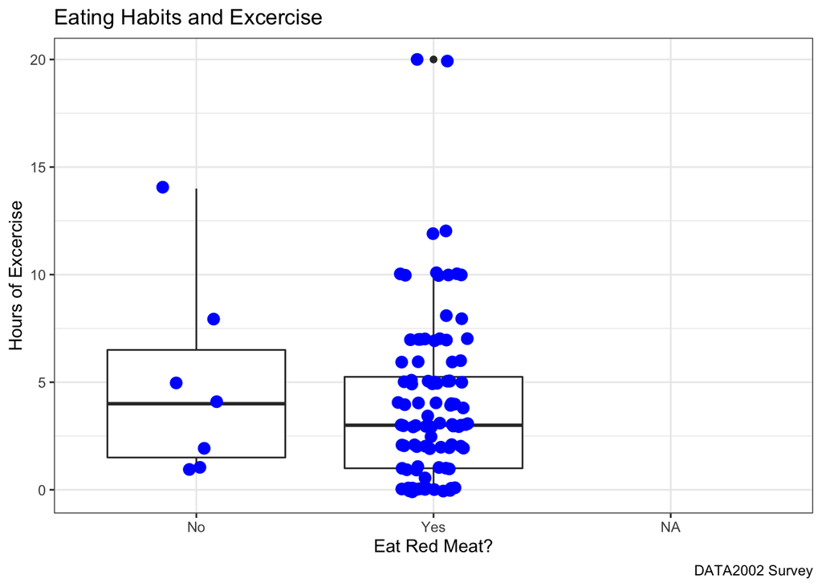

```r
ggplot(x, aes(x=Meat, y = `How many hours a week do you spend exercising?`)) + geom_boxplot() + geom_jitter(width=0.15, size=3, colour = "blue") + theme_bw() + labs(x="Eat Red Meat?", y="Hours of Excercise")+ggtitle("Eating Habits and Excercise")+labs(caption='DATA2002 Survey')
```

##### Performing a 2 sample T test.

This will demonstrate whether the 2 samples: meat eaters and non meaters, if their level of exercise is independent or dependent.

**1. Hypothesis:**
$$H0: μ_x = μ_y H1: μ_x \text{ does not equal } μ_y$$

**2. Assumptions:**
$$X_i,..... X_n \text{ are independent and identically distributed, }$$
$$Y_i,..... Y_n \text{ are independent and identically distributed.}$$
$$X_i's \text{ independent of } Y_i's$$

**3. Test Statistic:**
$$T = \frac{X-Y}{(S_p \sqrt(1/n_1+1/n_2))}$$
where
$$S^2_p= \frac{(n_x-1)S^2_x + (n_y-1)S^2_y}{n_x+n_y-2}$$
Under
$$H_0, T ~ t_n_x+T_n_y$$

```r
nM=101
nV=7
sM=3.866192
sV=4.690416
mM=4.0125
mV=5.0000
sP = sqrt(((nM - 1) * sM^2 + (nV - 1) * sV^2)/
(nM + nV - 2))

t0 = (mM - mV)/(sP * sqrt(1/nM + 1/nV))
t0
```

```
## [1] -0.6449533
```

**4. Observed Test Statistic:**
$$t_0 = -0.645$$

```r
deg_free = nM+nV-2
p_val = 2 * (1 - pt(abs(t0), deg_free))
p_val
```

```
## [1] 0.5203509
```

**5. P Value:**
$$P(X^2_1 \geq -0.645) = 0.5203$$

**6. Decision:** Since the P Value is greater than 0.05, we **retain the Null Hypothesis** and therefore there is no evidence that eating meat impacts the hours students excercise for.

$~$

### 3.2 Effect of University Club Participation on Exercise

Again, a separate variable was created (“TripleClub”) for whether people are part of 3 or more clubs or not. This allows us to similarly compare the summary statistics of the two groups.

```r
x$TripleClub <- ifelse(x$`How many university clubs are you a member of?` >= 3, "Yes", "No")

x %>% group_by(TripleClub) %>% summarize(Mean = mean(`How many hours a week do you spend exercising?`, na.rm=TRUE), SD = sd(`How many hours a week do you spend exercising?`, na.rm=TRUE), n=n())
```

```
## # A tibble: 2 x 4
##   TripleClub  Mean    SD     n
##   <chr>      <dbl> <dbl> <int>
## 1 No          4.22  4.10    81
## 2 Yes         3.68  3.33    29
```

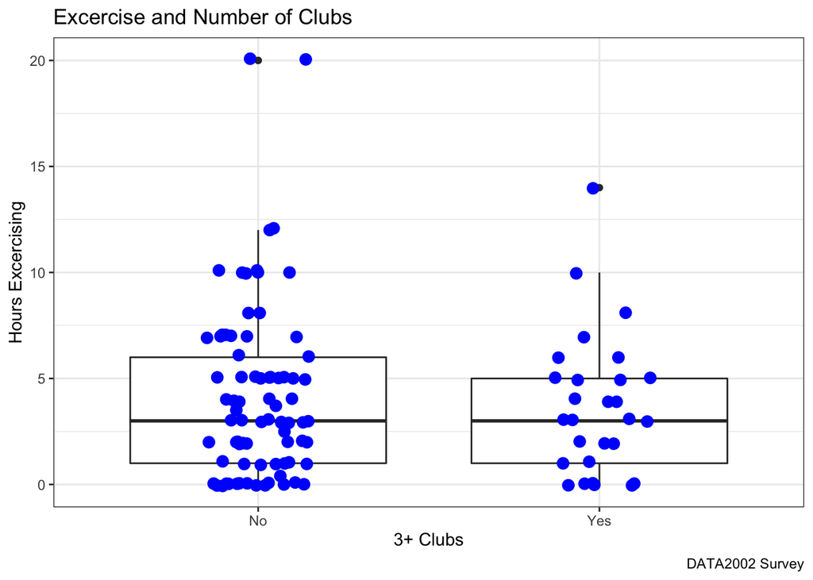

```r
ggplot(x, aes(x=TripleClub, y = `How many hours a week do you spend exercising?`)) + geom_boxplot() + geom_jitter(width=0.15, size=3, colour = "blue") + theme_bw() + labs(x="3+ Clubs", y="Hours Excercising")+ggtitle("Excercise and Number of Clubs")+labs(caption='DATA2002 Survey')
```

##### Performing a 2 sample T test.

This will demonstrate whether the 2 samples: members of 3 or more clubs versus other students, if their level of exercise is independent or dependent.

**1. Hypothesis:**
$$H0: μ_x = μ_y H1: μ_x \text{ does not equal } μ_y$$

**2. Assumptions:**
$$X_i,..... X_n \text{ are independent and identically distributed, }$$
$$Y_i,..... Y_n \text{ are independent and identically distributed.}$$
$$X_i's \text{ independent of } Y_i's$$

**3. Test Statistic:**
$$T = \frac{X-Y}{(S_p \sqrt(1/n_1+1/n_2))}$$
where
$$S^2_p= \frac{(n_x-1)S^2_x + (n_y-1)S^2_y}{n_x+n_y-2}$$
Under
$$H_0, T ~ t_n_x+T_n_y$$

```r
nY=29
nN=81
sY=3.333929
sN=4.101354
mY=3.678571
mN=4.218354
sP = sqrt(((nY - 1) * sY^2 + (nN - 1) * sN^2)/
(nY + nN - 2))

t0 = (mY - mN)/(sP * sqrt(1/nY + 1/nN))
t0
```

```
## [1] -0.6368347
```

**4. Observed Test Statistic:**
$$t_0 = -0.637$$

```r
deg_free = nY+nN-2
p_val = 2 * (1 - pt(abs(t0), deg_free))
p_val
```

```
## [1] 0.5255801
```

**5. P Value:**
$$P(X^2_1 \geq -0.637) = 0.5256$$

**6. Decision:** Since the P Value is greater than 0.05, we **retain the Null Hypothesis** and therefore there is no evidence that being apart of a students club impacts the hours students excercise for.

$~$

### 3.3 Effect of Living with Parents on Study Hours

To clean the study variable, it was reasoned that any reported value above 70 is infeasible, as this would require 10 hours a day, 7 days a week. The highest value below this cutoff was around 60, and everything above it was well into the hundreds or above, which we deem to be incorrectly reported values. Again, comparing summary statistics and creating a visualisation:

```r
x <- x %>% mutate(`On average, how many hours per week did you spend on university work last semester?` =
                    ifelse(`On average, how many hours per week did you spend on university work last semester?` < 70,
                           `On average, how many hours per week did you spend on university work last semester?`, NA))

x %>% group_by(`Do you currently live with your parents?`) %>% summarize(Mean = mean(`On average, how many hours per week did you spend on university work last semester?`, na.rm=TRUE), SD = sd(`On average, how many hours per week did you spend on university work last semester?`, na.rm=TRUE), n=n())
```

```
## # A tibble: 3 x 4
##   `Do you currently live with your parents?`  Mean    SD     n
##   <chr>                                      <dbl> <dbl> <int>
## 1 No                                          27.2  14.4    60
## 2 Yes                                         26.9  14.1    49
## 3 <NA>                                       NaN    NA       1
```

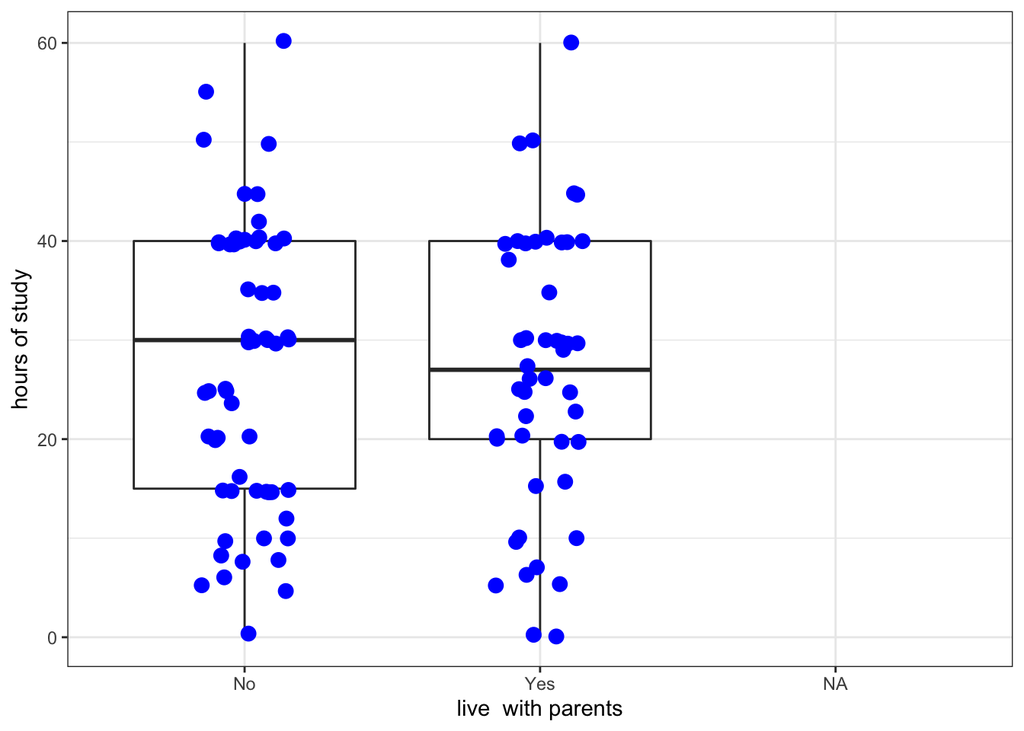

```r
ggplot(x, aes(x=`Do you currently live with your parents?`, y = `On average, how many hours per week did you spend on university work last semester?`)) + geom_boxplot() + geom_jitter(width=0.15, size=3, colour = "blue") + theme_bw() + labs(x="live  with parents", y="hours of study")
```

##### Performing a 2 sample T test.

**1. Hypothesis:**
$$H0: μ_x = μ_y H1: μ_x \text{ does not equal } μ_y$$

**2. Assumptions:**
$$X_i,..... X_n \text{ are independent and identically distributed, }$$
$$Y_i,..... Y_n \text{ are independent and identically distributed.}$$
$$X_i's \text{ independent of } Y_i's$$

**3. Test Statistic:**
$$T = \frac{X-Y}{(S_p \sqrt(1/n_1+1/n_2))}$$
where
$$S^2_p= \frac{(n_x-1)S^2_x + (n_y-1)S^2_y}{n_x+n_y-2}$$
Under
$$H_0, T ~ t_n_x+T_n_y$$

```r
nY=49
nN=60
sY=14.06326
sN=14.36131
mY=26.91489
mN=27.22414
sP = sqrt(((nY - 1) * sY^2 + (nN - 1) * sN^2)/
(nY + nN - 2))

t0 = (mY - mN)/(sP * sqrt(1/nY + 1/nN))
t0
```

```
## [1] -0.1128794
```

**4. Observed Test Statistic:**
$$t_0 = -0.113$$

```r
deg_free = nY+nN-2
p_val = 2 * (1 - pt(abs(t0), deg_free))
p_val
```

```
## [1] 0.9103377
```

**5. P Value:**
$$P(X^2_1 \geq -0.113) = 0.910$$

$~$ $~$

# 4. Further Data Analysis

### 4.1 Effect of Shoe Size on Height

For this question, a number of variables were refactored for simplicity or practicality. Firstly, gender was refactored to be either male (M), female (F), or null.

```r
x$Gender <- toupper(mapvalues(x$Gender %>% tolower,
                              from=c("female", "male", "man"),
                              to=c("f", "m", "m")))
x <- x %>% mutate(`Gender` = fct_lump(`Gender`, n = 2, other_level = NA))
```

Secondly, the shoe size variable was recoded using an online conversion guide (see Bibliography). This was because some shoe sizes were presented in EU sizing, whilst others in AUS/UK/US (these latter three have slight discrepancies but are generally within a size or two). This refactorisation also required segregating by gender.

```r
x <- x %>%
  mutate(`What is your shoe size?` =
           case_when(`Gender` == "M" ~
                       recode_factor(as.character(`What is your shoe size?`),
                                     "35.5"="3", "37"="4","38"="5","39"="6","40"="6",
                                     "40.5"="7","41"="7.5","42"="8","42.5"="8.5","43"="9",
                                     "44"="9.5","44.5"="10","45"="10.5","46"="11",
                                     "47"="12","48"="13","49.5"="14"),
                    `Gender` == "F" ~
                        recode_factor(as.character(`What is your shoe size?`),
                                      "35"="4","36"="5","37"="6","38"="7","39"="8",
                                      "40"="9","41"="10","42"="11")))
x$`What is your shoe size?` <- as.numeric(as.character(x$`What is your shoe size?`))  # converting back to numeric
x <- x %>% mutate(`What is your shoe size?` = ifelse(`What is your shoe size?` < 16, `What is your shoe size?`, NA))  # removing high values
```

Finally, a similar issue occurred in the reported heights. After removing obviously incorrect values, some were clearly recorded in metres whilst others were recorded in centimetres. For ease, all have been converted to centimetres.

```r
x <- x %>% mutate(`How tall are you?` = ifelse(`How tall are you?` < 210, ifelse(`How tall are you?` > 3, `How tall are you?`, `How tall are you?`*100), NA))
```

Due to differences between genders, it is best to approach testing this causality with regards to only one gender at a time. In either case, given these are both numerical variables, we frame our test as whether a linear regression between the two yields a statistically significant slope coefficient. Therefore assuming a regression model of $Y_i = \beta_0 + \beta_1X_i + e_i$, for either gender, our hypotheses are as follows:

**1. Hypotheses:**
$$H_0: \beta_1 = 0 \quad H_1: \beta_1 ≠ 0$$
**2. Assumptions** Conducting this test requires least squared regression assumptions. Since they are beyond the scope of this course (currently), they will not be scrutinised with great vigour, but most can be argued to hold intuitively or tested via residual plots.

**3. Test Statistic:**
$$T = \frac{\hat{\beta_1}-0}{SE(\hat{\beta_1})} \text{ under } H_0, T \sim \text{ student-}t \text{ distribution}$$
Starting with conducting a regression for the males:

```r
males <- x %>% filter(x$`Gender` == "M")
reg <- lm(`How tall are you?` ~ `What is your shoe size?`, data=males)
summary(reg)
```

```
##
## Call:
## lm(formula = `How tall are you?` ~ `What is your shoe size?`,
##     data = males)
##
## Residuals:
##      Min       1Q   Median       3Q      Max
## -17.4415  -3.1503   0.2041   3.7284  12.0731
##
## Coefficients:
##                           Estimate Std. Error t value             Pr(>|t|)
## (Intercept)               160.3152     3.7371  42.898 < 0.0000000000000002
## `What is your shoe size?`   1.9029     0.3676   5.176           0.00000277
##
## (Intercept)               ***
## `What is your shoe size?` ***
## ---
## Signif. codes:  0 '***' 0.001 '**' 0.01 '*' 0.05 '.' 0.1 ' ' 1
##
## Residual standard error: 5.656 on 60 degrees of freedom
##   (4 observations deleted due to missingness)
## Multiple R-squared:  0.3087, Adjusted R-squared:  0.2972
## F-statistic: 26.79 on 1 and 60 DF,  p-value: 0.000002766
```

The regression output reveals our observed test statistic to be 5.176.

**4. P-Value:**

$$P(t \geq 5.176) = 0.00000277 < 0.0001$$
**5. Decision:**

Since the p-value is extremely small, we can **reject the null hypothesis** at a 1% significance level and conclude shoe size is a statistically significant determinant of male height. Note additionally that the model estimates that for every extra shoe size, height will increase by roughly 2 centimetres. This fit, and the upward trend of the two variables, can be visualised on the scatter plot below.

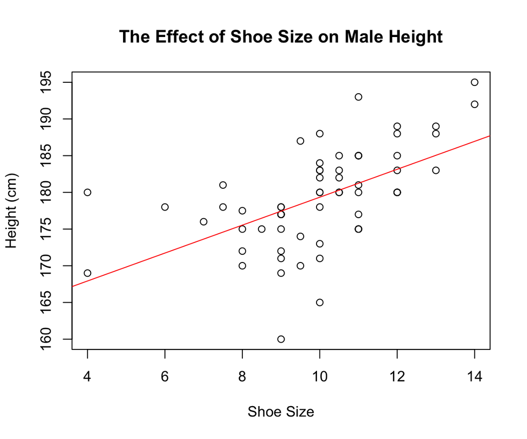

```r
plot(males$`What is your shoe size?`,males$`How tall are you?`, main="The Effect of Shoe Size on Male Height",
     xlab="Shoe Size", ylab="Height (cm)")
abline(a=160.3152,b=1.9029, col="red")
```

Now testing if similar correlation can be found for females:

```r
females <- x %>% filter(x$`Gender` == "F")
reg <- lm(`How tall are you?` ~ `What is your shoe size?`, data=females)
summary(reg)
```

```
##
## Call:
## lm(formula = `How tall are you?` ~ `What is your shoe size?`,
##     data = females)
##
## Residuals:
##      Min       1Q   Median       3Q      Max
## -10.7487  -3.3602  -0.5496   2.8097  12.0089
##
## Coefficients:
##                           Estimate Std. Error t value            Pr(>|t|)
## (Intercept)               154.1944     5.7153  26.979 <0.0000000000000002
## `What is your shoe size?`   1.3593     0.8519   1.596               0.119
##
## (Intercept)               ***
## `What is your shoe size?`
## ---
## Signif. codes:  0 '***' 0.001 '**' 0.01 '*' 0.05 '.' 0.1 ' ' 1
##
## Residual standard error: 5.707 on 38 degrees of freedom
##   (1 observation deleted due to missingness)
## Multiple R-squared:  0.0628, Adjusted R-squared:  0.03814
## F-statistic: 2.546 on 1 and 38 DF,  p-value: 0.1188
```

The regression output reveals our observed test statistic to be 1.596.

**4. P-Value:**
$$P(t \geq 1.596) = 0.119$$
**5. Decision:**

Since the p-value is quite large, we **cannot reject the null hypothesis** at even a 10% significance level. Therefore we conclude for females, shoe size is NOT a statistically significant determinant of height. This lack of fit can be visualised on the scatter plot below.

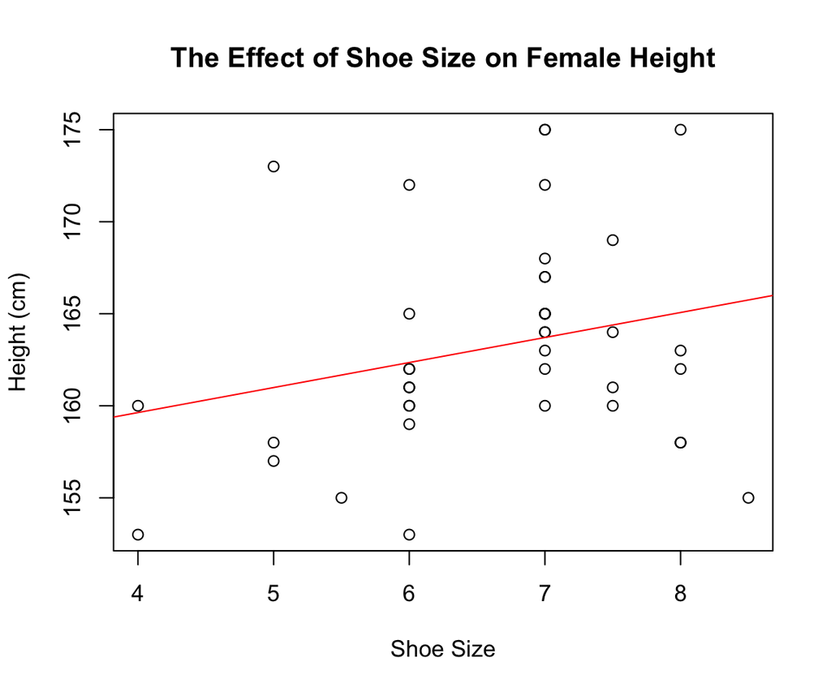

```r
plot(females$`What is your shoe size?`,females$`How tall are you?`, main="The Effect of Shoe Size on Female Height",
     xlab="Shoe Size", ylab="Height (cm)")
abline(a=154.1944,b=1.3593, col="red")
```

$~$

### 4.2 Effect of Handedness on Wearing Glasses

##### Performing Fisher’s Exact Test

This will demonstrate whether ‘handedness’ and needing glasses are independent or not.

**2. Assumptions:** As this is an ‘exact’ test we do not have to assume that the categories have to be greater than 5

```r
handed=recode(x$`What is your dominant hand?`, `Left handed` ="Left", `Right handed`="Right",.default = NA_character_)

tab=table(handed,x$`Do you wear glasses or contacts?`)
tab
```

```
##
## handed  No Yes
##   Left   5   4
##   Right 40  57
```

**3.Hypergeometric Distribution**
$$P(X \geqslant 40) = P(X =40,41,42,43,44,45)$$

```r
fisher.test(tab)
```

```
##
##  Fisher's Exact Test for Count Data
##
## data:  tab
## p-value = 0.4901
## alternative hypothesis: true odds ratio is not equal to 1
## 95 percent confidence interval:
##  0.3567146 9.5107571
## sample estimates:
## odds ratio
##   1.771318
```

**4. P Value:** 0.4901

**5. Decision:** Since the P Value is greater than 0.05, we **retain the null hypothesis** and therefore the sample data supports the claim that handedness and needing glasses is independent.

$~$

### 4.3 Effect of Living with Parents on Pet Ownership

**1. Hypothesis:** H0:
$$p_ij =P_i\times P_j for i = 1,2 and j =1,2$$
H1: At least one equality does not hold.

**2. Assumptions:**
$$e_ij = y_i\times y_j/n ≥ 5$$

```r
table(x$`Do you currently live with your parents?`,x$`Did you have a pet growing up?`)
```

```
##
##       No Yes
##   No  35  25
##   Yes 13  36
```

**3. Test Statistic:**
$$T = \sum_{i=1}^{2}\sum_{j=1}^{2} \frac{(y_i\times y_j/n)^2}{y_i\times y_j/n}. Under H_0 T ∼ χ_1^2$$

##### Chi Squared Test of Independence

```r
y=c(35,13,25,36)
n=sum(y)
c=2
r=2
y.mat = matrix(y, nrow = r, ncol = c)
chisq.test(y.mat)
```

```
##
##  Pearson's Chi-squared test with Yates' continuity correction
##
## data:  y.mat
## X-squared = 9.8167, df = 1, p-value = 0.001729
```

**6. Decision:** Since the P Value is less than 0.05, we **reject the Null Hypothesis** and can state that having a pet whilst growing up means you are more likey to be living at home.

$~$ $~$

# 5. Bibliography

##### In-Text References

Finder Australia, 2019, *The ultimate international shoe size conversion guide*, viewed 19 September 2019, https://www.finder.com.au/shoe-size-conversion-guide.

##### Coding Packages

Gregory Demin (2019). expss: Tables, Labels and Some Useful Functions for Spreadsheets. R package version 0.9.1. URL: http://CRAN.r-project.org/package=expss.

Hadley Wickham (2017). tidyverse: Easily Install and Load the ‘Tidyverse’. R package version 1.2.1. URL: https://CRAN.R-project.org/package=tidyverse.

Hadley Wickham (2019). ggplot2: Elegant Graphics for Data Analysis. R package version 3.2.1. URL: http://CRAN.r-project.org/package=ggplot2.

Hadley Wickham, Romain François, Lionel Henry and Kirill Müller (2019). dplyr: A Grammar of Data Manipulation. R package version 0.8.3. URL: https://CRAN.R-project.org/package=dplyr.

R Core Team (2019). R: A language and environment for statistical computing. R Foundation for Statistical Computing, Vienna, Austria. URL: https://www.R-project.org/.